# Capstone Project: Create a Customer Segmentation Report for Arvato Financial Services

In this project, you will analyze demographics data for customers of a mail-order sales company in Germany, comparing it against demographics information for the general population. You'll use unsupervised learning techniques to perform customer segmentation, identifying the parts of the population that best describe the core customer base of the company. Then, you'll apply what you've learned on a third dataset with demographics information for targets of a marketing campaign for the company, and use a model to predict which individuals are most likely to convert into becoming customers for the company. The data that you will use has been provided by our partners at Bertelsmann Arvato Analytics, and represents a real-life data science task.

If you completed the first term of this program, you will be familiar with the first part of this project, from the unsupervised learning project. The versions of those two datasets used in this project will include many more features and has not been pre-cleaned. You are also free to choose whatever approach you'd like to analyzing the data rather than follow pre-determined steps. In your work on this project, make sure that you carefully document your steps and decisions, since your main deliverable for this project will be a blog post reporting your findings.

```python
# import libraries here; add more as necessary
import numpy as np
import pandas as pd
import matplotlib.pyplot as plt
import seaborn as sns
import datetime
from sklearn.preprocessing import StandardScaler
from sklearn.decomposition import PCA
from sklearn.cluster import KMeans, MiniBatchKMeans
from sklearn.externals import joblib
#from sklearn.cross_validation import StratifiedKFold
from sklearn.model_selection import train_test_split
from xgboost import XGBClassifier
#from lightgbm import LGBMClassifier, LGBMRegressor
from sklearn.metrics import make_scorer, f1_score, roc_auc_score

# magic word for producing visualizations in notebook
%matplotlib inline
```

## Part 0: Get to Know the Data

Each row of the demographics files represents a single person, but also includes information outside of individuals, including information about their household, building, and neighborhood. Use the information from the first two files to figure out how customers ("CUSTOMERS") are similar to or differ from the general population at large ("AZDIAS"), then use your analysis to make predictions on the other two files ("MAILOUT"), predicting which recipients are most likely to become a customer for the mail-order company.

The "CUSTOMERS" file contains three extra columns ('CUSTOMER_GROUP', 'ONLINE_PURCHASE', and 'PRODUCT_GROUP'), which provide broad information about the customers depicted in the file. The original "MAILOUT" file included one additional column, "RESPONSE", which indicated whether or not each recipient became a customer of the company. For the "TRAIN" subset, this column has been retained, but in the "TEST" subset it has been removed; it is against that withheld column that your final predictions will be assessed in the Kaggle competition.

Otherwise, all of the remaining columns are the same between the three data files. For more information about the columns depicted in the files, you can refer to two Excel spreadsheets provided in the workspace. One of them is a top-level list of attributes and descriptions, organized by informational category. The other is a detailed mapping of data values for each feature in alphabetical order.

In the below cell, we've provided some initial code to load in the first two datasets. Note for all of the `.csv` data files in this project that they're semicolon (`;`) delimited, so an additional argument in the [`read_csv()`](https://pandas.pydata.org/pandas-docs/stable/generated/pandas.read_csv.html) call has been included to read in the data properly. Also, considering the size of the datasets, it may take some time for them to load completely.

You'll notice when the data is loaded in that a warning message will immediately pop up. Before you really start digging into the modeling and analysis, you're going to need to perform some cleaning. Take some time to browse the structure of the data and look over the informational spreadsheets to understand the data values. Make some decisions on which features to keep, which features to drop, and if any revisions need to be made on data formats. It'll be a good idea to create a function with pre-processing steps, since you'll need to clean all of the datasets before you work with them.

### Load in all data files

```python
# load in the data
azdias = pd.read_csv('Udacity_AZDIAS_052018.csv', sep=';')
customers = pd.read_csv('Udacity_CUSTOMERS_052018.csv', sep=';')
azdias.head()
```

```
/Users/mtx/anaconda/envs/dlnd-tf-lab/lib/python3.5/site-packages/IPython/core/interactiveshell.py:2717: DtypeWarning: Columns (18,19) have mixed types. Specify dtype option on import or set low_memory=False.
  interactivity=interactivity, compiler=compiler, result=result)
```

|  | LNR | AGER_TYP | AKT_DAT_KL | ALTER_HH | ALTER_KIND1 | ALTER_KIND2 | ALTER_KIND3 | ALTER_KIND4 | ALTERSKATEGORIE_FEIN | ANZ_HAUSHALTE_AKTIV | ... | VHN | VK_DHT4A | VK_DISTANZ | VK_ZG11 | W_KEIT_KIND_HH | WOHNDAUER_2008 | WOHNLAGE | ZABEOTYP | ANREDE_KZ | ALTERSKATEGORIE_GROB |
| --- | --- | --- | --- | --- | --- | --- | --- | --- | --- | --- | --- | --- | --- | --- | --- | --- | --- | --- | --- | --- | --- |
| 0 | 910215 | -1 | NaN | NaN | NaN | NaN | NaN | NaN | NaN | NaN | ... | NaN | NaN | NaN | NaN | NaN | NaN | NaN | 3 | 1 | 2 |
| 1 | 910220 | -1 | 9.0 | 0.0 | NaN | NaN | NaN | NaN | 21.0 | 11.0 | ... | 4.0 | 8.0 | 11.0 | 10.0 | 3.0 | 9.0 | 4.0 | 5 | 2 | 1 |
| 2 | 910225 | -1 | 9.0 | 17.0 | NaN | NaN | NaN | NaN | 17.0 | 10.0 | ... | 2.0 | 9.0 | 9.0 | 6.0 | 3.0 | 9.0 | 2.0 | 5 | 2 | 3 |
| 3 | 910226 | 2 | 1.0 | 13.0 | NaN | NaN | NaN | NaN | 13.0 | 1.0 | ... | 0.0 | 7.0 | 10.0 | 11.0 | NaN | 9.0 | 7.0 | 3 | 2 | 4 |
| 4 | 910241 | -1 | 1.0 | 20.0 | NaN | NaN | NaN | NaN | 14.0 | 3.0 | ... | 2.0 | 3.0 | 5.0 | 4.0 | 2.0 | 9.0 | 3.0 | 4 | 1 | 3 |

5 rows × 366 columns

```python
df_train0 = pd.read_csv('Udacity_MAILOUT_052018_TRAIN.csv', sep=';')
df_test0 = pd.read_csv('Udacity_MAILOUT_052018_TEST.csv', sep=';')
df_train0.head()
```

|  | LNR | AGER_TYP | AKT_DAT_KL | ALTER_HH | ALTER_KIND1 | ALTER_KIND2 | ALTER_KIND3 | ALTER_KIND4 | ALTERSKATEGORIE_FEIN | ANZ_HAUSHALTE_AKTIV | ... | VK_DHT4A | VK_DISTANZ | VK_ZG11 | W_KEIT_KIND_HH | WOHNDAUER_2008 | WOHNLAGE | ZABEOTYP | RESPONSE | ANREDE_KZ | ALTERSKATEGORIE_GROB |
| --- | --- | --- | --- | --- | --- | --- | --- | --- | --- | --- | --- | --- | --- | --- | --- | --- | --- | --- | --- | --- | --- |
| 0 | 1763 | 2 | 1.0 | 8.0 | NaN | NaN | NaN | NaN | 8.0 | 15.0 | ... | 5.0 | 2.0 | 1.0 | 6.0 | 9.0 | 3.0 | 3 | 0 | 2 | 4 |
| 1 | 1771 | 1 | 4.0 | 13.0 | NaN | NaN | NaN | NaN | 13.0 | 1.0 | ... | 1.0 | 2.0 | 1.0 | 4.0 | 9.0 | 7.0 | 1 | 0 | 2 | 3 |
| 2 | 1776 | 1 | 1.0 | 9.0 | NaN | NaN | NaN | NaN | 7.0 | 0.0 | ... | 6.0 | 4.0 | 2.0 | NaN | 9.0 | 2.0 | 3 | 0 | 1 | 4 |
| 3 | 1460 | 2 | 1.0 | 6.0 | NaN | NaN | NaN | NaN | 6.0 | 4.0 | ... | 8.0 | 11.0 | 11.0 | 6.0 | 9.0 | 1.0 | 3 | 0 | 2 | 4 |
| 4 | 1783 | 2 | 1.0 | 9.0 | NaN | NaN | NaN | NaN | 9.0 | 53.0 | ... | 2.0 | 2.0 | 1.0 | 6.0 | 9.0 | 3.0 | 3 | 0 | 1 | 3 |

5 rows × 367 columns

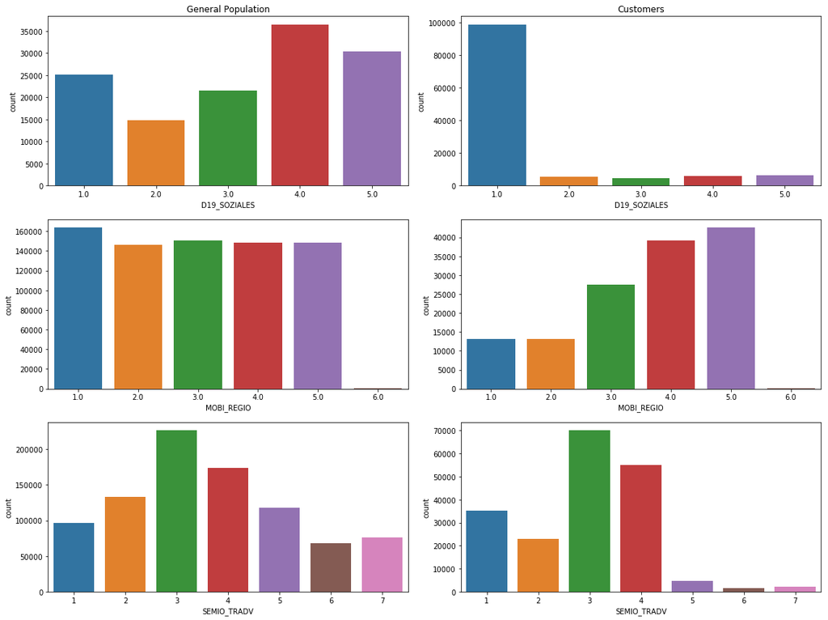

```python
#feat_list = ['KK_KUNDENTYP','WOHNLAGE','VHN','D19_SOZIALES','MOBI_REGIO','SEMIO_TRADV']
feat_list = ['D19_SOZIALES','MOBI_REGIO','SEMIO_TRADV']
f,ax = plt.subplots(len(feat_list),2,figsize=(16,4*len(feat_list)))

for ind,i in enumerate(feat_list):
    ax = plt.subplot(len(feat_list),2,2*ind+1)
    if ind == 0:
        plt.title('General Population')
    sns.countplot(azdias[azdias[i]>0][i],ax=ax)

    ax = plt.subplot(len(feat_list),2,2*ind+2)
    if ind == 0:
        plt.title('Customers')
    sns.countplot(customers[customers[i]>0][i],ax=ax)

plt.tight_layout()
```

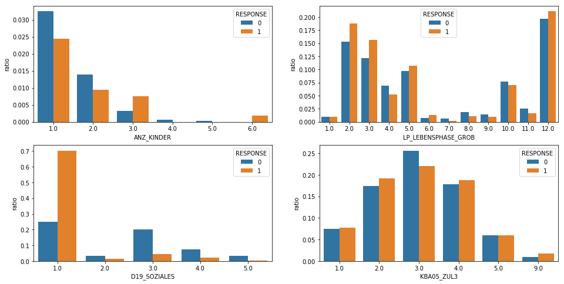

```python
feat_list = ['ANZ_KINDER','LP_LEBENSPHASE_GROB','D19_SOZIALES','KBA05_ZUL3']
is_response = df_train0[df_train0['RESPONSE']==1]
na_response = df_train0[df_train0['RESPONSE']==0]
row_cnt = int(np.ceil(len(feat_list)/2))
f,ax = plt.subplots(row_cnt,2,figsize=(16,4*row_cnt))
for ind,i in enumerate(feat_list):

    a1 = pd.DataFrame(is_response[i].value_counts()/len(is_response))
    a1['RESPONSE'] = 1
    a2 = pd.DataFrame(na_response[i].value_counts()/len(na_response))
    a2['RESPONSE'] = 0
    a = pd.concat([a1,a2]).reset_index().rename(columns={i:'ratio','index':i})
    ax = plt.subplot(row_cnt,2,ind+1)
    sns.barplot(x=i,y='ratio',data=a[a[i]>0],hue='RESPONSE',ax=ax)
```

### Configuring of data dictionary

In order to understand and clean the data, we are going to figure out **data types**, **null values**, and value meanings for all columns.

So far, the references I am able to collected are:

- `AZDIAS_Feature_Summary.csv`: File from other project, which contains the most useful information we need about Type and Unknown values. However it covers only **85** features;
- `DIAS Attributes - Values 2017.xlsx`: File from current project, which provides value meanings but **no** type info.

In this section, I will build a full dictionary by combining above two files, with extra manual edit for most data type info ( some are just guessing.)

```python
feature_summary0 = pd.read_csv('dictionary/AZDIAS_Feature_Summary.csv', delimiter = ';')
X = 'X'
XX = 'XX'
feature_summary0['missing_or_unknown'] = feature_summary0['missing_or_unknown'].apply(lambda x: eval(x))
feature_summary0.head()
```

|  | attribute | information_level | type | missing_or_unknown |
| --- | --- | --- | --- | --- |
| 0 | AGER_TYP | person | categorical | [-1, 0] |
| 1 | ALTERSKATEGORIE_GROB | person | ordinal | [-1, 0, 9] |
| 2 | ANREDE_KZ | person | categorical | [-1, 0] |
| 3 | CJT_GESAMTTYP | person | categorical | [0] |
| 4 | FINANZ_MINIMALIST | person | ordinal | [-1] |

##### `Attributes-Values` file preprocessing

**Type info**: According to the value meanings for each column, I am able to manually categorized all recorded columns into 5 Types: 'categorical', 'ordinal', 'interval', 'numeric', 'mixed';

```python
attribute_value_xls = pd.read_excel('dictionary/DIAS Attributes - Values 2017.xlsx')
#attribute_value_xls.drop(columns=['Unnamed: 0'],inplace=True)
attribute_value_xls = attribute_value_xls.ffill()
attribute_value_xls.head()
```

|  | Type | Attribute | Description | Value | Meaning |
| --- | --- | --- | --- | --- | --- |
| 0 | categorical | AGER_TYP | best-ager typology | -1 | unknown |
| 1 | categorical | AGER_TYP | best-ager typology | 0 | no classification possible |
| 2 | categorical | AGER_TYP | best-ager typology | 1 | passive elderly |
| 3 | categorical | AGER_TYP | best-ager typology | 2 | cultural elderly |
| 4 | categorical | AGER_TYP | best-ager typology | 3 | experience-driven elderly |

```python
attribute_value_xls[attribute_value_xls['Meaning'].apply(lambda x:1 if 'know' in x else 0) == 1]['Meaning'].value_counts()
```

```
unknown                                                           232
no transaction known                                               34
no transactions known                                              22
mixed building without actually known household or comapny          1
mixed building without actually known company                       1
residental building buildings without actually known household      1
unknown / no main age detectable                                    1
company building w/o known company                                  1
mixed building without actually known household                     1
Name: Meaning, dtype: int64
```

**Null Value**: By extracting keyword info, we are able to filter out null values definitions:

- unknown;
- no transaction known;
- no transactions known;
- unknown / no main age detectable;

```python
ukn_str_lst = ['unknown','no transaction known','no transactions known','unknown / no main age detectable']
attribute_value_xls[attribute_value_xls['Meaning'].apply(lambda x:1 if x in ukn_str_lst else 0) == 1]['Meaning'].value_counts()
```

```
unknown                             232
no transaction known                 34
no transactions known                22
unknown / no main age detectable      1
Name: Meaning, dtype: int64
```

#### Undocumented Features

Even though we got two reference file, there are still features not documented. From below we found 90 features in `azdias` dataframe are still unknown.

```python
undocumented_features = set(azdias.columns) - set(feature_summary0['attribute']) - set(attribute_value_xls['Attribute'])
len(undocumented_features),undocumented_features
```

```
(90,
 {'AKT_DAT_KL',
  'ALTERSKATEGORIE_FEIN',
  'ALTER_KIND1',
  'ALTER_KIND2',
  'ALTER_KIND3',
  'ALTER_KIND4',
  'ANZ_KINDER',
  'ANZ_STATISTISCHE_HAUSHALTE',
  'CJT_KATALOGNUTZER',
  'CJT_TYP_1',
  'CJT_TYP_2',
  'CJT_TYP_3',
  'CJT_TYP_4',
  'CJT_TYP_5',
  'CJT_TYP_6',
  'D19_BANKEN_DIREKT',
  'D19_BANKEN_GROSS',
  'D19_BANKEN_LOKAL',
  'D19_BANKEN_REST',
  'D19_BEKLEIDUNG_GEH',
  'D19_BEKLEIDUNG_REST',
  'D19_BILDUNG',
  'D19_BIO_OEKO',
  'D19_BUCH_CD',
  'D19_DIGIT_SERV',
  'D19_DROGERIEARTIKEL',
  'D19_ENERGIE',
  'D19_FREIZEIT',
  'D19_GARTEN',
  'D19_HANDWERK',
  'D19_HAUS_DEKO',
  'D19_KINDERARTIKEL',
  'D19_KONSUMTYP_MAX',
  'D19_KOSMETIK',
  'D19_LEBENSMITTEL',
  'D19_LETZTER_KAUF_BRANCHE',
  'D19_LOTTO',
  'D19_NAHRUNGSERGAENZUNG',
  'D19_RATGEBER',
```

[output cut: 36 more lines]

```
  'LNR',
  'MOBI_RASTER',
  'RT_KEIN_ANREIZ',
  'RT_SCHNAEPPCHEN',
  'RT_UEBERGROESSE',
  'STRUKTURTYP',
  'UMFELD_ALT',
  'UMFELD_JUNG',
  'UNGLEICHENN_FLAG',
  'VERDICHTUNGSRAUM',
  'VHA',
  'VHN',
  'VK_DHT4A',
  'VK_DISTANZ',
  'VK_ZG11'})
```

```python
set(attribute_value_xls['Attribute']) - set(azdias.columns)
```

```
{'BIP_FLAG',
 'CAMEO_DEUINTL_2015',
 'D19_BANKEN_DIREKT_RZ',
 'D19_BANKEN_GROSS_RZ',
 'D19_BANKEN_LOKAL_RZ',
 'D19_BANKEN_REST_RZ',
 'D19_BEKLEIDUNG_GEH_RZ',
 'D19_BEKLEIDUNG_REST_RZ',
 'D19_BILDUNG_RZ',
 'D19_BIO_OEKO_RZ',
 'D19_BUCH_RZ',
 'D19_DIGIT_SERV_RZ',
 'D19_DROGERIEARTIKEL_RZ',
 'D19_ENERGIE_RZ',
 'D19_FREIZEIT_RZ',
 'D19_GARTEN_RZ',
 'D19_HANDWERK_RZ',
 'D19_HAUS_DEKO_RZ',
 'D19_KINDERARTIKEL_RZ',
 'D19_KK_KUNDENTYP',
 'D19_KOSMETIK_RZ',
 'D19_LEBENSMITTEL_RZ',
 'D19_LOTTO_RZ',
 'D19_NAHRUNGSERGAENZUNG_RZ',
 'D19_RATGEBER_RZ',
 'D19_REISEN_RZ',
 'D19_SAMMELARTIKEL_RZ',
 'D19_SCHUHE_RZ',
 'D19_SONSTIGE_RZ',
 'D19_TECHNIK_RZ',
 'D19_TELKO_MOBILE_RZ',
 'D19_TELKO_REST_RZ',
 'D19_TIERARTIKEL_RZ',
 'D19_VERSAND_REST_RZ',
 'D19_VERSICHERUNGEN_RZ',
 'D19_VOLLSORTIMENT_RZ',
 'D19_WEIN_FEINKOST_RZ',
 'GEOSCORE_KLS7',
 'HAUSHALTSSTRUKTUR',
 'KBA13_CCM_1400_2500',
 'SOHO_FLAG',
 'WACHSTUMSGEBIET_NB'}
```

#### Feature Name Trimming

By further examing, I did find some feature names starting with D19 are similar in `DIAS Attributes - Values 2017.xlsx` and `azdiaz` dataframe, except for they ends with '_RZ' in the dict file while not in dataframe.

After renamed those features, we still got 57 undocumented features.

```python
attribute_value_xls['Attribute'] = attribute_value_xls['Attribute'].apply(lambda x: x.replace('_RZ','') if 'D19' in x else x)
undocumented_features = set(azdias.columns) - set(feature_summary0['attribute']) - set(attribute_value_xls['Attribute'])
len(undocumented_features),undocumented_features
```

```
(57,
 {'AKT_DAT_KL',
  'ALTERSKATEGORIE_FEIN',
  'ALTER_KIND1',
  'ALTER_KIND2',
  'ALTER_KIND3',
  'ALTER_KIND4',
  'ANZ_KINDER',
  'ANZ_STATISTISCHE_HAUSHALTE',
  'CJT_KATALOGNUTZER',
  'CJT_TYP_1',
  'CJT_TYP_2',
  'CJT_TYP_3',
  'CJT_TYP_4',
  'CJT_TYP_5',
  'CJT_TYP_6',
  'D19_BUCH_CD',
  'D19_KONSUMTYP_MAX',
  'D19_LETZTER_KAUF_BRANCHE',
  'D19_SOZIALES',
  'D19_TELKO_ONLINE_QUOTE_12',
  'D19_VERSI_DATUM',
  'D19_VERSI_OFFLINE_DATUM',
  'D19_VERSI_ONLINE_DATUM',
  'D19_VERSI_ONLINE_QUOTE_12',
  'DSL_FLAG',
  'EINGEFUEGT_AM',
  'EINGEZOGENAM_HH_JAHR',
  'EXTSEL992',
  'FIRMENDICHTE',
  'GEMEINDETYP',
  'HH_DELTA_FLAG',
  'KBA13_ANTG1',
  'KBA13_ANTG2',
  'KBA13_ANTG3',
  'KBA13_ANTG4',
  'KBA13_BAUMAX',
  'KBA13_CCM_1401_2500',
  'KBA13_GBZ',
  'KBA13_HHZ',
  'KBA13_KMH_210',
  'KOMBIALTER',
  'KONSUMZELLE',
  'LNR',
  'MOBI_RASTER',
  'RT_KEIN_ANREIZ',
  'RT_SCHNAEPPCHEN',
  'RT_UEBERGROESSE',
  'STRUKTURTYP',
  'UMFELD_ALT',
  'UMFELD_JUNG',
  'UNGLEICHENN_FLAG',
  'VERDICHTUNGSRAUM',
  'VHA',
  'VHN',
  'VK_DHT4A',
  'VK_DISTANZ',
  'VK_ZG11'})
```

Delete useless feature in dictionary file.

```python
useless_feat = list(set(attribute_value_xls['Attribute']) - set(azdias.columns))
useless_feat
```

```
['SOHO_FLAG',
 'WACHSTUMSGEBIET_NB',
 'D19_KK_KUNDENTYP',
 'CAMEO_DEUINTL_2015',
 'KBA13_CCM_1400_2500',
 'BIP_FLAG',
 'GEOSCORE_KLS7',
 'HAUSHALTSSTRUKTUR',
 'D19_BUCH']
```

```python
attribute_value_xls = attribute_value_xls[~attribute_value_xls['Attribute'].isin(useless_feat)]
attribute_value_xls = attribute_value_xls[~attribute_value_xls['Attribute'].isin(set(feature_summary0['attribute']))]
attribute_value_xls.head()
```

|  | Type | Attribute | Description | Value | Meaning |
| --- | --- | --- | --- | --- | --- |
| 138 | ordinal | D19_BANKEN_ANZ_12 | transaction activity BANKS in the last 12 months | 0 | no transactions known |
| 139 | ordinal | D19_BANKEN_ANZ_12 | transaction activity BANKS in the last 12 months | 1 | very low activity |
| 140 | ordinal | D19_BANKEN_ANZ_12 | transaction activity BANKS in the last 12 months | 2 | low activity |
| 141 | ordinal | D19_BANKEN_ANZ_12 | transaction activity BANKS in the last 12 months | 3 | slightly increased activity |
| 142 | ordinal | D19_BANKEN_ANZ_12 | transaction activity BANKS in the last 12 months | 4 | increased activity |

#### Null Value definition

Parse null value definition for features already documented.

```python
na_att_xls = attribute_value_xls[attribute_value_xls['Meaning'].apply(lambda x:1 if x in ukn_str_lst else 0) == 1]
na_att_xls['Value'] = na_att_xls['Value'].astype(str)
na_att_xls['Value'] = na_att_xls['Value'].apply(lambda x: eval(x))
na_att_xls
```

|  | Type | Attribute | Description | Value | Meaning |
| --- | --- | --- | --- | --- | --- |
| 138 | ordinal | D19_BANKEN_ANZ_12 | transaction activity BANKS in the last 12 months | 0 | no transactions known |
| 145 | ordinal | D19_BANKEN_ANZ_24 | transaction activity BANKS in the last 24 months | 0 | no transactions known |
| 161 | ordinal | D19_BANKEN_DATUM | actuality of the last transaction for the segm... | 10 | no transactions known |
| 162 | categorical | D19_BANKEN_DIREKT | transactional activity based on the product gr... | 0 | no transaction known |
| 170 | categorical | D19_BANKEN_GROSS | transactional activity based on the product gr... | 0 | no transaction known |
| 178 | categorical | D19_BANKEN_LOKAL | transactional activity based on the product gr... | 0 | no transaction known |
| 195 | ordinal | D19_BANKEN_OFFLINE_DATUM | actuality of the last transaction for the segm... | 10 | no transactions known |
| 205 | ordinal | D19_BANKEN_ONLINE_DATUM | actuality of the last transaction for the segm... | 10 | no transactions known |
| 217 | categorical | D19_BANKEN_REST | transactional activity based on the product gr... | 0 | no transaction known |
| 225 | categorical | D19_BEKLEIDUNG_GEH | transactional activity based on the product gr... | 0 | no transaction known |
| 233 | categorical | D19_BEKLEIDUNG_REST | transactional activity based on the product gr... | 0 | no transaction known |
| 241 | categorical | D19_BILDUNG | transactional activity based on the product gr... | 0 | no transaction known |
| 249 | categorical | D19_BIO_OEKO | transactional activity based on the product gr... | 0 | no transaction known |
| 265 | categorical | D19_DIGIT_SERV | transactional activity based on the product gr... | 0 | no transaction known |
| 273 | categorical | D19_DROGERIEARTIKEL | transactional activity based on the product gr... | 0 | no transaction known |
| 281 | categorical | D19_ENERGIE | transactional activity based on the product gr... | 0 | no transaction known |
| 289 | categorical | D19_FREIZEIT | transactional activity based on the product gr... | 0 | no transaction known |
| 297 | categorical | D19_GARTEN | transactional activity based on the product gr... | 0 | no transaction known |
| 305 | ordinal | D19_GESAMT_ANZ_12 | transaction activity TOTAL POOL in the last 12... | 0 | no transactions known |
| 312 | ordinal | D19_GESAMT_ANZ_24 | transaction activity TOTAL POOL in the last 24... | 0 | no transactions known |
| 328 | ordinal | D19_GESAMT_DATUM | actuality of the last transaction with the com... | 10 | no transactions known |
| 338 | ordinal | D19_GESAMT_OFFLINE_DATUM | actuality of the last transaction with the com... | 10 | no transactions known |
| 348 | ordinal | D19_GESAMT_ONLINE_DATUM | actuality of the last transaction with the com... | 10 | no transactions known |
| 360 | categorical | D19_HANDWERK | transactional activity based on the product gr... | 0 | no transaction known |
| 368 | categorical | D19_HAUS_DEKO | transactional activity based on the product gr... | 0 | no transaction known |
| 376 | categorical | D19_KINDERARTIKEL | transactional activity based on the product gr... | 0 | no transaction known |
| 398 | categorical | D19_KOSMETIK | transactional activity based on the product gr... | 0 | no transaction known |
| 406 | categorical | D19_LEBENSMITTEL | transactional activity based on the product gr... | 0 | no transaction known |
| 414 | categorical | D19_LOTTO | transactional activity based on the product gr... | 0 | no transaction known |
| 422 | categorical | D19_NAHRUNGSERGAENZUNG | transactional activity based on the product gr... | 0 | no transaction known |
| ... | ... | ... | ... | ... | ... |
| 1671 | ordinal | KBA13_MOTOR | most common motor size within the PLZ8 | -1 | unknown |
| 1677 | ordinal | KBA13_NISSAN | share of NISSAN within the PLZ8 | -1 | unknown |
| 1684 | ordinal | KBA13_OPEL | share of OPEL within the PLZ8 | -1 | unknown |
| 1691 | ordinal | KBA13_PEUGEOT | share of PEUGEOT within the PLZ8 | -1 | unknown |
| 1698 | ordinal | KBA13_RENAULT | share of RENAULT within the PLZ8 | -1 | unknown |
| 1705 | ordinal | KBA13_SEG_GELAENDEWAGEN | share of allterrain within the PLZ8 | -1 | unknown |
| 1712 | ordinal | KBA13_SEG_GROSSRAUMVANS | share of big sized vans within the PLZ8 | -1 | unknown |
| 1719 | ordinal | KBA13_SEG_KLEINST | share of very small cars (Ford Ka etc.) in the... | -1 | unknown |
| 1726 | ordinal | KBA13_SEG_KLEINWAGEN | share of small and very small cars (Ford Fiest... | -1 | unknown |
| 1733 | ordinal | KBA13_SEG_KOMPAKTKLASSE | share of lowe midclass cars (Ford Focus etc.) ... | -1 | unknown |
| 1740 | ordinal | KBA13_SEG_MINIVANS | share of minivans within the PLZ8 | -1 | unknown |
| 1747 | ordinal | KBA13_SEG_MINIWAGEN | share of minicars within the PLZ8 | -1 | unknown |
| 1754 | ordinal | KBA13_SEG_MITTELKLASSE | share of middle class cars (Ford Mondeo etc.) ... | -1 | unknown |
| 1761 | ordinal | KBA13_SEG_OBEREMITTELKLASSE | share of upper middle class cars and upper cla... | -1 | unknown |
| 1768 | ordinal | KBA13_SEG_OBERKLASSE | share of upper class cars (BMW 7er etc.) in th... | -1 | unknown |
| 1775 | ordinal | KBA13_SEG_SONSTIGE | share of other cars within the PLZ8 | -1 | unknown |
| 1782 | ordinal | KBA13_SEG_SPORTWAGEN | share of sportscars within the PLZ8 | -1 | unknown |
| 1789 | ordinal | KBA13_SEG_UTILITIES | share of MUVs/SUVs within the PLZ8 | -1 | unknown |
| 1796 | ordinal | KBA13_SEG_VAN | share of vans within the PLZ8 | -1 | unknown |
| 1803 | ordinal | KBA13_SEG_WOHNMOBILE | share of roadmobiles within the PLZ8 | -1 | unknown |
| 1810 | ordinal | KBA13_SITZE_4 | number of cars with less than 5 seats in the PLZ8 | -1 | unknown |
| 1817 | ordinal | KBA13_SITZE_5 | number of cars with 5 seats in the PLZ8 | -1 | unknown |
| 1824 | ordinal | KBA13_SITZE_6 | number of cars with more than 5 seats in the PLZ8 | -1 | unknown |
| 1831 | ordinal | KBA13_TOYOTA | share of TOYOTA within the PLZ8 | -1 | unknown |
| 1838 | ordinal | KBA13_VORB_0 | share of cars with no preowner - PLZ8 | -1 | unknown |
| 1845 | ordinal | KBA13_VORB_1 | share of cars with 1 preowner - PLZ8 | -1 | unknown |
| 1852 | ordinal | KBA13_VORB_1_2 | share of cars with 1 or 2 preowner - PLZ8 | -1 | unknown |
| 1859 | ordinal | KBA13_VORB_2 | share of cars with 2 preowner - PLZ8 | -1 | unknown |
| 1866 | ordinal | KBA13_VORB_3 | share of cars with 3 or more preowner - PLZ8 | -1 | unknown |
| 1873 | ordinal | KBA13_VW | share of VOLKSWAGEN within the PLZ8 | -1 | unknown |

220 rows × 5 columns

```python
len(attribute_value_xls.Attribute.unique()),len(na_att_xls),len(na_att_xls['Attribute'].unique())
```

```
(224, 220, 220)
```

### Combining references

I build a complete dictionary of **name**, **type**, and **null values** for dataset features by following parts:

- Base: features from `AZDIAS_Feature_Summary.csv`
- part2: features parsed from `DIAS Attributes - Values 2017.xlsx` that have specific Null values;
- part3: features parsed from `DIAS Attributes - Values 2017.xlsx` with no specific Null values;
- part4: features in dataset but undocumented.

```python
part2 = na_att_xls[['Attribute','Type','Value']].drop_duplicates().reset_index(drop=True)
part2
```

|  | Attribute | Type | Value |
| --- | --- | --- | --- |
| 0 | D19_BANKEN_ANZ_12 | ordinal | 0 |
| 1 | D19_BANKEN_ANZ_24 | ordinal | 0 |
| 2 | D19_BANKEN_DATUM | ordinal | 10 |
| 3 | D19_BANKEN_DIREKT | categorical | 0 |
| 4 | D19_BANKEN_GROSS | categorical | 0 |
| 5 | D19_BANKEN_LOKAL | categorical | 0 |
| 6 | D19_BANKEN_OFFLINE_DATUM | ordinal | 10 |
| 7 | D19_BANKEN_ONLINE_DATUM | ordinal | 10 |
| 8 | D19_BANKEN_REST | categorical | 0 |
| 9 | D19_BEKLEIDUNG_GEH | categorical | 0 |
| 10 | D19_BEKLEIDUNG_REST | categorical | 0 |
| 11 | D19_BILDUNG | categorical | 0 |
| 12 | D19_BIO_OEKO | categorical | 0 |
| 13 | D19_DIGIT_SERV | categorical | 0 |
| 14 | D19_DROGERIEARTIKEL | categorical | 0 |
| 15 | D19_ENERGIE | categorical | 0 |
| 16 | D19_FREIZEIT | categorical | 0 |
| 17 | D19_GARTEN | categorical | 0 |
| 18 | D19_GESAMT_ANZ_12 | ordinal | 0 |
| 19 | D19_GESAMT_ANZ_24 | ordinal | 0 |
| 20 | D19_GESAMT_DATUM | ordinal | 10 |
| 21 | D19_GESAMT_OFFLINE_DATUM | ordinal | 10 |
| 22 | D19_GESAMT_ONLINE_DATUM | ordinal | 10 |
| 23 | D19_HANDWERK | categorical | 0 |
| 24 | D19_HAUS_DEKO | categorical | 0 |
| 25 | D19_KINDERARTIKEL | categorical | 0 |
| 26 | D19_KOSMETIK | categorical | 0 |
| 27 | D19_LEBENSMITTEL | categorical | 0 |
| 28 | D19_LOTTO | categorical | 0 |
| 29 | D19_NAHRUNGSERGAENZUNG | categorical | 0 |
| ... | ... | ... | ... |
| 190 | KBA13_MOTOR | ordinal | -1 |
| 191 | KBA13_NISSAN | ordinal | -1 |
| 192 | KBA13_OPEL | ordinal | -1 |
| 193 | KBA13_PEUGEOT | ordinal | -1 |
| 194 | KBA13_RENAULT | ordinal | -1 |
| 195 | KBA13_SEG_GELAENDEWAGEN | ordinal | -1 |
| 196 | KBA13_SEG_GROSSRAUMVANS | ordinal | -1 |
| 197 | KBA13_SEG_KLEINST | ordinal | -1 |
| 198 | KBA13_SEG_KLEINWAGEN | ordinal | -1 |
| 199 | KBA13_SEG_KOMPAKTKLASSE | ordinal | -1 |
| 200 | KBA13_SEG_MINIVANS | ordinal | -1 |
| 201 | KBA13_SEG_MINIWAGEN | ordinal | -1 |
| 202 | KBA13_SEG_MITTELKLASSE | ordinal | -1 |
| 203 | KBA13_SEG_OBEREMITTELKLASSE | ordinal | -1 |
| 204 | KBA13_SEG_OBERKLASSE | ordinal | -1 |
| 205 | KBA13_SEG_SONSTIGE | ordinal | -1 |
| 206 | KBA13_SEG_SPORTWAGEN | ordinal | -1 |
| 207 | KBA13_SEG_UTILITIES | ordinal | -1 |
| 208 | KBA13_SEG_VAN | ordinal | -1 |
| 209 | KBA13_SEG_WOHNMOBILE | ordinal | -1 |
| 210 | KBA13_SITZE_4 | ordinal | -1 |
| 211 | KBA13_SITZE_5 | ordinal | -1 |
| 212 | KBA13_SITZE_6 | ordinal | -1 |
| 213 | KBA13_TOYOTA | ordinal | -1 |
| 214 | KBA13_VORB_0 | ordinal | -1 |
| 215 | KBA13_VORB_1 | ordinal | -1 |
| 216 | KBA13_VORB_1_2 | ordinal | -1 |
| 217 | KBA13_VORB_2 | ordinal | -1 |
| 218 | KBA13_VORB_3 | ordinal | -1 |
| 219 | KBA13_VW | ordinal | -1 |

220 rows × 3 columns

```python
part3 = attribute_value_xls[~attribute_value_xls['Attribute'].isin(na_att_xls['Attribute'].unique().tolist())][['Attribute','Type']]#.drop_duplicates(inplace=True)
part3 = part3.drop_duplicates().reset_index(drop=True)
part3
```

|  | Attribute | Type |
| --- | --- | --- |
| 0 | D19_BANKEN_ONLINE_QUOTE_12 | interval |
| 1 | D19_GESAMT_ONLINE_QUOTE_12 | interval |
| 2 | D19_KONSUMTYP | categorical |
| 3 | D19_VERSAND_ONLINE_QUOTE_12 | interval |

```python
feature_summary0 = feature_summary0.rename(columns={'attribute': 'Attribute', 'missing_or_unknown': 'Value','type':'Type'})#[['Attribute','Type','Value']]
feature_summary0.head()
```

|  | Attribute | information_level | Type | Value |
| --- | --- | --- | --- | --- |
| 0 | AGER_TYP | person | categorical | [-1, 0] |
| 1 | ALTERSKATEGORIE_GROB | person | ordinal | [-1, 0, 9] |
| 2 | ANREDE_KZ | person | categorical | [-1, 0] |
| 3 | CJT_GESAMTTYP | person | categorical | [0] |
| 4 | FINANZ_MINIMALIST | person | ordinal | [-1] |

```python
part4 = pd.DataFrame()
part4['Attribute'] = list(undocumented_features)
```

```python
feature_dict0 = pd.concat([feature_summary0,part2,part3,part4]).reset_index(drop=True)
feature_dict0.sort_values('Attribute')
```

|  | Attribute | Type | Value | information_level |
| --- | --- | --- | --- | --- |
| 0 | AGER_TYP | categorical | [-1, 0] | person |
| 333 | AKT_DAT_KL | NaN | NaN | NaN |
| 326 | ALTERSKATEGORIE_FEIN | NaN | NaN | NaN |
| 1 | ALTERSKATEGORIE_GROB | ordinal | [-1, 0, 9] | person |
| 43 | ALTER_HH | interval | [0] | household |
| 345 | ALTER_KIND1 | NaN | NaN | NaN |
| 329 | ALTER_KIND2 | NaN | NaN | NaN |
| 328 | ALTER_KIND3 | NaN | NaN | NaN |
| 331 | ALTER_KIND4 | NaN | NaN | NaN |
| 2 | ANREDE_KZ | categorical | [-1, 0] | person |
| 50 | ANZ_HAUSHALTE_AKTIV | numeric | [0] | building |
| 51 | ANZ_HH_TITEL | numeric | [] | building |
| 354 | ANZ_KINDER | NaN | NaN | NaN |
| 44 | ANZ_PERSONEN | numeric | [] | household |
| 315 | ANZ_STATISTISCHE_HAUSHALTE | NaN | NaN | NaN |
| 45 | ANZ_TITEL | numeric | [] | household |
| 82 | ARBEIT | ordinal | [-1, 9] | community |
| 66 | BALLRAUM | ordinal | [-1] | postcode |
| 57 | CAMEO_DEUG_2015 | categorical | [-1, X] | microcell_rr4 |
| 58 | CAMEO_DEU_2015 | categorical | [XX] | microcell_rr4 |
| 59 | CAMEO_INTL_2015 | mixed | [-1, XX] | microcell_rr4 |
| 3 | CJT_GESAMTTYP | categorical | [0] | person |
| 346 | CJT_KATALOGNUTZER | NaN | NaN | NaN |
| 319 | CJT_TYP_1 | NaN | NaN | NaN |
| 321 | CJT_TYP_2 | NaN | NaN | NaN |
| 347 | CJT_TYP_3 | NaN | NaN | NaN |
| 340 | CJT_TYP_4 | NaN | NaN | NaN |
| 343 | CJT_TYP_5 | NaN | NaN | NaN |
| 337 | CJT_TYP_6 | NaN | NaN | NaN |
| 85 | D19_BANKEN_ANZ_12 | ordinal | 0 | NaN |
| ... | ... | ... | ... | ... |
| 25 | SEMIO_FAM | ordinal | [-1, 9] | person |
| 35 | SEMIO_KAEM | ordinal | [-1, 9] | person |
| 33 | SEMIO_KRIT | ordinal | [-1, 9] | person |
| 31 | SEMIO_KULT | ordinal | [-1, 9] | person |
| 29 | SEMIO_LUST | ordinal | [-1, 9] | person |
| 27 | SEMIO_MAT | ordinal | [-1, 9] | person |
| 36 | SEMIO_PFLICHT | ordinal | [-1, 9] | person |
| 32 | SEMIO_RAT | ordinal | [-1, 9] | person |
| 26 | SEMIO_REL | ordinal | [-1, 9] | person |
| 24 | SEMIO_SOZ | ordinal | [-1, 9] | person |
| 37 | SEMIO_TRADV | ordinal | [-1, 9] | person |
| 28 | SEMIO_VERT | ordinal | [-1, 9] | person |
| 38 | SHOPPER_TYP | categorical | [-1] | person |
| 39 | SOHO_KZ | categorical | [-1] | person |
| 351 | STRUKTURTYP | NaN | NaN | NaN |
| 40 | TITEL_KZ | categorical | [-1, 0] | person |
| 322 | UMFELD_ALT | NaN | NaN | NaN |
| 336 | UMFELD_JUNG | NaN | NaN | NaN |
| 309 | UNGLEICHENN_FLAG | NaN | NaN | NaN |
| 327 | VERDICHTUNGSRAUM | NaN | NaN | NaN |
| 41 | VERS_TYP | categorical | [-1] | person |
| 353 | VHA | NaN | NaN | NaN |
| 365 | VHN | NaN | NaN | NaN |
| 342 | VK_DHT4A | NaN | NaN | NaN |
| 341 | VK_DISTANZ | NaN | NaN | NaN |
| 362 | VK_ZG11 | NaN | NaN | NaN |
| 49 | WOHNDAUER_2008 | ordinal | [-1, 0] | household |
| 56 | WOHNLAGE | mixed | [-1] | building |
| 48 | W_KEIT_KIND_HH | ordinal | [-1, 0] | household |
| 42 | ZABEOTYP | categorical | [-1, 9] | person |

366 rows × 4 columns

#### Double check that the dictionary and dataset columns matches.

```python
len(feature_dict0.Attribute.unique()),len(azdias.columns)
```

```
(366, 366)
```

```python
set(feature_dict0.Attribute.unique())-set(azdias.columns),set(azdias.columns)-set(feature_dict0.Attribute.unique())
```

```
(set(), set())
```

```python
feature_dict0.to_csv('feature_dict.csv')
```

### Load dictionary files after manual editing

Note that we still need information for undocumented features from above file `feature_dict.csv`. So I manually guessed the data types for those 57 features.

For data engineering usage we need to differentiate **Numerical** and **Categorical** feature, finally I set almost all other features to be `numerical` except two: **D19_LETZTER_KAUF_BRANCHE**, **D19_SOZIALES**;

- D19_LETZTER_KAUF_BRANCHE: definitely categorical because of its values seem like other column names;
- D19_SOZIALES: probably categorical due to other features with similar names are categorical.

```python
feature_dict = pd.read_excel('dictionary/feature_dict1.xlsx')
X = 'X'
XX = 'XX'
feature_dict['Value'] = feature_dict['Value'].apply(lambda x: np.nan if str(x) == 'nan' else eval(str(x)))
feature_dict
```

|  | Attribute | Type | Value | information_level |
| --- | --- | --- | --- | --- |
| 0 | AGER_TYP | categorical | [-1, 0] | person |
| 1 | AKT_DAT_KL | o | NaN | NaN |
| 2 | ALTER_HH | interval | [0] | household |
| 3 | ALTER_KIND1 | o | NaN | NaN |
| 4 | ALTER_KIND2 | o | NaN | NaN |
| 5 | ALTER_KIND3 | o | NaN | NaN |
| 6 | ALTER_KIND4 | o | NaN | NaN |
| 7 | ALTERSKATEGORIE_FEIN | o0 | NaN | NaN |
| 8 | ALTERSKATEGORIE_GROB | ordinal | [-1, 0, 9] | person |
| 9 | ANREDE_KZ | categorical | [-1, 0] | person |
| 10 | ANZ_HAUSHALTE_AKTIV | numeric | [0] | building |
| 11 | ANZ_HH_TITEL | numeric | [] | building |
| 12 | ANZ_KINDER | o0 | NaN | NaN |
| 13 | ANZ_PERSONEN | numeric | [] | household |
| 14 | ANZ_STATISTISCHE_HAUSHALTE | o | NaN | NaN |
| 15 | ANZ_TITEL | numeric | [] | household |
| 16 | ARBEIT | ordinal | [-1, 9] | community |
| 17 | BALLRAUM | ordinal | [-1] | postcode |
| 18 | CAMEO_DEU_2015 | categorical | [XX] | microcell_rr4 |
| 19 | CAMEO_DEUG_2015 | categorical | [-1, X] | microcell_rr4 |
| 20 | CAMEO_INTL_2015 | mixed | [-1, XX] | microcell_rr4 |
| 21 | CJT_GESAMTTYP | categorical | [0] | person |
| 22 | CJT_KATALOGNUTZER | o | NaN | NaN |
| 23 | CJT_TYP_1 | o | NaN | NaN |
| 24 | CJT_TYP_2 | o | NaN | NaN |
| 25 | CJT_TYP_3 | o | NaN | NaN |
| 26 | CJT_TYP_4 | o | NaN | NaN |
| 27 | CJT_TYP_5 | o | NaN | NaN |
| 28 | CJT_TYP_6 | o | NaN | NaN |
| 29 | D19_BANKEN_ANZ_12 | ordinal | 0 | NaN |
| ... | ... | ... | ... | ... |
| 336 | SEMIO_FAM | ordinal | [-1, 9] | person |
| 337 | SEMIO_KAEM | ordinal | [-1, 9] | person |
| 338 | SEMIO_KRIT | ordinal | [-1, 9] | person |
| 339 | SEMIO_KULT | ordinal | [-1, 9] | person |
| 340 | SEMIO_LUST | ordinal | [-1, 9] | person |
| 341 | SEMIO_MAT | ordinal | [-1, 9] | person |
| 342 | SEMIO_PFLICHT | ordinal | [-1, 9] | person |
| 343 | SEMIO_RAT | ordinal | [-1, 9] | person |
| 344 | SEMIO_REL | ordinal | [-1, 9] | person |
| 345 | SEMIO_SOZ | ordinal | [-1, 9] | person |
| 346 | SEMIO_TRADV | ordinal | [-1, 9] | person |
| 347 | SEMIO_VERT | ordinal | [-1, 9] | person |
| 348 | SHOPPER_TYP | categorical | [-1] | person |
| 349 | SOHO_KZ | categorical | [-1] | person |
| 350 | STRUKTURTYP | o | NaN | NaN |
| 351 | TITEL_KZ | categorical | [-1, 0] | person |
| 352 | UMFELD_ALT | o | NaN | NaN |
| 353 | UMFELD_JUNG | o | NaN | NaN |
| 354 | UNGLEICHENN_FLAG | b | NaN | NaN |
| 355 | VERDICHTUNGSRAUM | o | NaN | NaN |
| 356 | VERS_TYP | categorical | [-1] | person |
| 357 | VHA | o0 | NaN | NaN |
| 358 | VHN | o0 | NaN | NaN |
| 359 | VK_DHT4A | o | NaN | NaN |
| 360 | VK_DISTANZ | o | NaN | NaN |
| 361 | VK_ZG11 | o | NaN | NaN |
| 362 | W_KEIT_KIND_HH | ordinal | [-1, 0] | household |
| 363 | WOHNDAUER_2008 | ordinal | [-1, 0] | household |
| 364 | WOHNLAGE | mo | [-1] | building |
| 365 | ZABEOTYP | categorical | [-1, 9] | person |

366 rows × 4 columns

```python
# Be sure to add in a lot more cells (both markdown and code) to document your
# approach and findings!
```

### Preprocess for dataset

- Replace **UNKNOWN** or **Missing** values with `np.nan`;
- Data Type fixing: set `category` type on categorical features, and turn other features into numerical.

```python
def try2float(x):
    try:
        return float(x)
    except:
        return str(x)

def try2int(x):
    try:
        return int(x)
    except:
        return str(x)

def preproc_na_typ(df,df_dict):
    count = 0
    for index,row in df_dict.iterrows():
        count += 1
        feat = row.Attribute
        nans = row.Value
        if feat not in df.columns:
            continue

        if isinstance(nans, int) or isinstance(nans, float):
            df[feat] = df[feat].apply(lambda x: np.nan if x == nans else x)
        else:
            df[feat] = df[feat].apply(lambda x: np.nan if x in nans else x)

        if row['Type'] == 'dt':
            df[feat] = df[feat].apply(lambda x: np.nan if str(x)=='nan' else datetime.date.toordinal(datetime.datetime.strptime(str(x),"%Y-%m-%d %H:%M:%S")))
        elif row['Type'] in ['c','c0','categorical','mc']:
            df[feat] = df[feat].apply(lambda x:np.nan if str(x)=='nan' else try2int(x)).astype('category')
        else:
            df[feat] = df[feat].apply(lambda x:np.nan if str(x)=='nan' else try2int(x))

        if count%20 == 0:
            print(datetime.datetime.now(),'Processed:',count)

    return df
```

```python
azdias1 = preproc_na_typ(azdias.copy(),feature_dict)
azdias1.head()
```

```
2019-03-22 18:03:32.663021 Processed: 20
2019-03-22 18:03:47.181971 Processed: 40
2019-03-22 18:04:01.662911 Processed: 60
2019-03-22 18:04:15.621956 Processed: 80
2019-03-22 18:04:36.242771 Processed: 100
2019-03-22 18:04:51.725365 Processed: 120
2019-03-22 18:05:06.452082 Processed: 140
2019-03-22 18:05:22.415248 Processed: 160
2019-03-22 18:05:37.580150 Processed: 180
2019-03-22 18:05:52.018202 Processed: 200
2019-03-22 18:06:06.390216 Processed: 220
2019-03-22 18:06:20.722048 Processed: 240
2019-03-22 18:06:35.065955 Processed: 260
2019-03-22 18:06:49.441284 Processed: 280
2019-03-22 18:07:03.799639 Processed: 300
2019-03-22 18:07:21.632451 Processed: 320
2019-03-22 18:07:36.484757 Processed: 340
2019-03-22 18:07:51.825403 Processed: 360
```

|  | LNR | AGER_TYP | AKT_DAT_KL | ALTER_HH | ALTER_KIND1 | ALTER_KIND2 | ALTER_KIND3 | ALTER_KIND4 | ALTERSKATEGORIE_FEIN | ANZ_HAUSHALTE_AKTIV | ... | VHN | VK_DHT4A | VK_DISTANZ | VK_ZG11 | W_KEIT_KIND_HH | WOHNDAUER_2008 | WOHNLAGE | ZABEOTYP | ANREDE_KZ | ALTERSKATEGORIE_GROB |
| --- | --- | --- | --- | --- | --- | --- | --- | --- | --- | --- | --- | --- | --- | --- | --- | --- | --- | --- | --- | --- | --- |
| 0 | 910215 | NaN | NaN | NaN | NaN | NaN | NaN | NaN | NaN | NaN | ... | NaN | NaN | NaN | NaN | NaN | NaN | NaN | 3 | 1 | 2.0 |
| 1 | 910220 | NaN | 9.0 | NaN | NaN | NaN | NaN | NaN | 21.0 | 11.0 | ... | 4.0 | 8.0 | 11.0 | 10.0 | 3.0 | 9.0 | 4.0 | 5 | 2 | 1.0 |
| 2 | 910225 | NaN | 9.0 | 17.0 | NaN | NaN | NaN | NaN | 17.0 | 10.0 | ... | 2.0 | 9.0 | 9.0 | 6.0 | 3.0 | 9.0 | 2.0 | 5 | 2 | 3.0 |
| 3 | 910226 | 2.0 | 1.0 | 13.0 | NaN | NaN | NaN | NaN | 13.0 | 1.0 | ... | 0.0 | 7.0 | 10.0 | 11.0 | NaN | 9.0 | 7.0 | 3 | 2 | 4.0 |
| 4 | 910241 | NaN | 1.0 | 20.0 | NaN | NaN | NaN | NaN | 14.0 | 3.0 | ... | 2.0 | 3.0 | 5.0 | 4.0 | 2.0 | 9.0 | 3.0 | 4 | 1 | 3.0 |

5 rows × 366 columns

### Acessing Null values

Statistics for null rate of each column.

```python
null_stat = pd.concat([azdias.isnull().mean(),azdias1.isnull().mean()],axis=1)
null_stat = null_stat.reset_index()
null_stat = null_stat.rename(columns={'index':'Attribute',0:'orig', 1:'na_rate'}).sort_values('na_rate',ascending=False)
null_stat[:5]
```

|  | Attribute | orig | na_rate |
| --- | --- | --- | --- |
| 7 | ALTER_KIND4 | 0.998648 | 0.998648 |
| 349 | TITEL_KZ | 0.082470 | 0.997576 |
| 6 | ALTER_KIND3 | 0.993077 | 0.993077 |
| 76 | D19_TELKO_ONLINE_DATUM | 0.000000 | 0.990796 |
| 33 | D19_BANKEN_LOKAL | 0.000000 | 0.981513 |

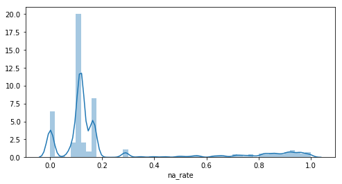

```python
f,ax = plt.subplots(figsize=(8,4))
sns.distplot(null_stat['na_rate'],ax=ax)
```

##### Specific Feature Engineering for CAMEO_INTL_2015

According to value meanings, I devided feature `CAMEO_INTL_2015` into two ordinal features, `wealthy level` and `age level`.

```python
azdias1['CAMEO_INTL_2015a'] = azdias1['CAMEO_INTL_2015'].apply(lambda x:np.nan if str(x)=='nan' else int(str(x)[0]))
azdias1['CAMEO_INTL_2015b'] = azdias1['CAMEO_INTL_2015'].apply(lambda x:np.nan if str(x)=='nan' else int(str(x)[1]))
len(azdias1.columns)
```

```
368
```

##### Drop columns with null value rate greater than 30%

```python
drop_cols = null_stat[null_stat['na_rate']>0.3]['Attribute'].tolist()
azdias1 = azdias1.drop(drop_cols+['LNR','CAMEO_INTL_2015'],axis=1)
asdias_col0 = azdias1.columns.tolist()
len(asdias_col0)
```

```
299
```

##### Statistics for null rate of each row

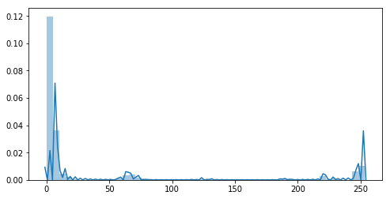

```python
s1 = azdias1.isnull().sum(axis=1).sort_values(ascending=False)
f,ax = plt.subplots(figsize=(8,4))
sns.distplot(s1,ax=ax)
```

##### According to the distribution of null rate, we will consider rows with more than 20 null values to be outliers.

```python
#Q3 + 1.5*IQR = 8 + 1.5*(8-0) = 20
s1.describe()
```

```
count    891221.000000
mean         33.630966
std          75.996304
min           0.000000
25%           0.000000
50%           1.000000
75%           8.000000
max         253.000000
dtype: float64
```

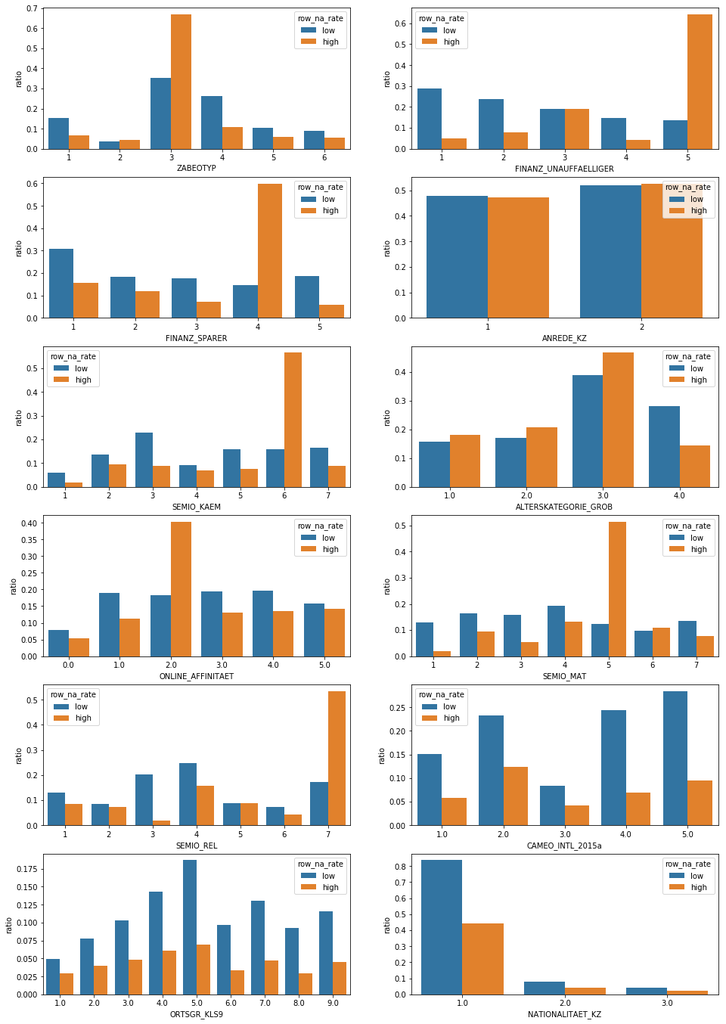

```python
selected_features = ['ZABEOTYP', 'FINANZ_UNAUFFAELLIGER', 'FINANZ_SPARER',
                     'ANREDE_KZ', 'SEMIO_KAEM', 'ALTERSKATEGORIE_GROB',
                     'ONLINE_AFFINITAET', 'SEMIO_MAT', 'SEMIO_REL',
                     'CAMEO_INTL_2015a', 'ORTSGR_KLS9', 'NATIONALITAET_KZ'
                    ]
nrow = 2
ncol = int(len(selected_features)/nrow)
azdias1['chk'] = azdias1.isnull().sum(axis=1).apply(lambda x:1 if x>20 else 0)

f,ax = plt.subplots(nrow,ncol,figsize = (16, 24))
for i,c in enumerate(selected_features):
    ax = plt.subplot(ncol, nrow, i+1)

    df0 = pd.DataFrame()
    df0['ratio'] = azdias1[azdias1['chk']==0].groupby(c).size()/len(azdias1[azdias1['chk']==0])
    df0['row_na_rate'] = 'low'
    df0 = df0.reset_index().rename(columns={c:'value'})

    df1 = pd.DataFrame()
    df1['ratio'] = azdias1[azdias1['chk']==1].groupby(c).size()/len(azdias1[azdias1['chk']==1])
    df1['row_na_rate'] = 'high'
    df1 = df1.reset_index().rename(columns={c:'value'})

    dft = pd.concat([df0,df1])
    sns.barplot(x='value',y='ratio',hue='row_na_rate',data=dft,ax=ax)
    plt.xlabel(c)

    #sns.countplot(x = c, hue = 'chk', data = azdias1, ax = ax)
```

##### Droping rows with more than 20 null values

From above histogram distribution, we randomly picked some feature to observe difference between rows with null values greater than and less than 20. For some features, the distribution are similar. While some features, like `FINANZ_SPARER`, got one or more outstanding values.

In this case, I will drop those rows first, while keep the high null-rate rows as a specific group for analysis.

```python
azdias1 = azdias1[azdias1['chk']==0]
azdias1.drop('chk',axis=1,inplace=True)
len(azdias1.columns[azdias1.isnull().any()].tolist()),azdias1.shape
```

```
(69, (734341, 299))
```

### Data Engineering

##### One-Hot Encoding for categorical features

```python
azdias1 = pd.get_dummies(azdias1)
len(azdias1.columns[azdias1.isnull().any()].tolist()),azdias1.shape
```

```
(52, (734341, 539))
```

##### Replace remain null cells with the most frequent value in each column

```python
for i in azdias1.columns[azdias1.isnull().any()].tolist():
    top_val = azdias1.groupby(i).size().sort_values(ascending=False).index[0]
    azdias1[i].fillna(top_val, inplace=True)
```

##### Scale the dataset

```python
scaler = StandardScaler()
azdias2 = azdias1.copy()
azdias2 = scaler.fit_transform(azdias2)

azdias2 = pd.DataFrame(data=azdias2, index=azdias1.index, columns=azdias1.columns)
azdias2.head()
```

|  | AKT_DAT_KL | ALTERSKATEGORIE_FEIN | ANZ_HAUSHALTE_AKTIV | ANZ_HH_TITEL | ANZ_KINDER | ANZ_PERSONEN | ANZ_STATISTISCHE_HAUSHALTE | ANZ_TITEL | ARBEIT | BALLRAUM | ... | VERS_TYP_1.0 | VERS_TYP_2.0 | ZABEOTYP_1 | ZABEOTYP_2 | ZABEOTYP_3 | ZABEOTYP_4 | ZABEOTYP_5 | ZABEOTYP_6 | ANREDE_KZ_1 | ANREDE_KZ_2 |
| --- | --- | --- | --- | --- | --- | --- | --- | --- | --- | --- | --- | --- | --- | --- | --- | --- | --- | --- | --- | --- | --- |
| 1 | 1.260460 | 1.560398 | 0.186421 | -0.125357 | -0.299106 | 0.223700 | 0.335475 | -0.060624 | -0.183045 | 0.849453 | ... | -0.907892 | 0.995192 | -0.427432 | -0.192365 | -0.740434 | -0.597351 | 2.948930 | -0.313743 | -0.958497 | 0.958497 |
| 2 | 1.260460 | 0.673877 | 0.120203 | -0.125357 | -0.299106 | -0.635082 | -0.031894 | -0.060624 | -0.183045 | -0.980639 | ... | 1.101452 | -1.004831 | -0.427432 | -0.192365 | -0.740434 | -0.597351 | 2.948930 | -0.313743 | -0.958497 | 0.958497 |
| 3 | -0.935447 | -0.212644 | -0.475767 | -0.125357 | -0.299106 | -1.493864 | -0.399263 | -0.060624 | -1.188897 | -0.065593 | ... | 1.101452 | -1.004831 | -0.427432 | -0.192365 | 1.350559 | -0.597351 | -0.339106 | -0.313743 | -0.958497 | 0.958497 |
| 4 | -0.935447 | 0.008986 | -0.343329 | -0.125357 | -0.299106 | 1.941264 | -0.325789 | -0.060624 | 0.822808 | -0.980639 | ... | -0.907892 | 0.995192 | -0.427432 | -0.192365 | -0.740434 | 1.674059 | -0.339106 | -0.313743 | 1.043300 | -1.043300 |
| 5 | -0.935447 | -0.877535 | -0.210892 | -0.125357 | -0.299106 | -0.635082 | -0.399263 | -0.060624 | -1.188897 | 0.849453 | ... | -0.907892 | 0.995192 | -0.427432 | -0.192365 | -0.740434 | 1.674059 | -0.339106 | -0.313743 | -0.958497 | 0.958497 |

5 rows × 539 columns

##### Dimension Reduction with PCA

```python
%%time
pca = PCA().fit(azdias2)
```

```
CPU times: user 1min 25s, sys: 25.1 s, total: 1min 50s
Wall time: 31.2 s
```

```
threshold_idx: 18
```

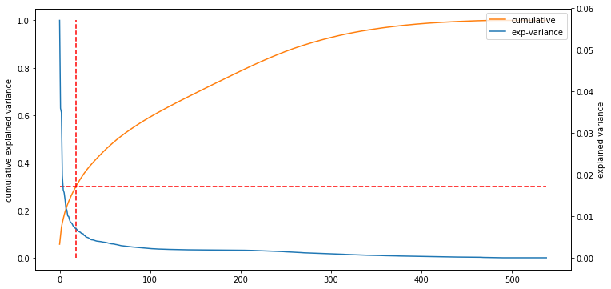

```python
f,ax = plt.subplots(figsize=(12,6))
l0 = plt.plot(pca.explained_variance_ratio_.cumsum(),color=sns.color_palette()[1],label='cumulative')
plt.ylabel('cumulative explained variance')

threshold = .3
threshold_idx = np.argmin(np.abs(threshold - pca.explained_variance_ratio_.cumsum()))
print('threshold_idx:',threshold_idx)
h_line = np.ones(len(pca.explained_variance_ratio_))*threshold
y_vline = [0, 1]
x_vline = np.ones(len(y_vline))*threshold_idx
plt.plot(np.arange(len(pca.explained_variance_ratio_)), h_line, 'r--')
plt.plot(x_vline, y_vline, 'r--')

plt.twinx()
l1 = plt.plot(pca.explained_variance_ratio_,color=sns.color_palette()[0],label='exp-variance')

plt.xlabel('number of components')
plt.ylabel('explained variance')
lns = l0 + l1
labs = [l.get_label() for l in lns]
plt.legend(lns, labs, loc='best')
```

##### PCA components selection

From above curve plot, we see that 18 or more components are able to explain 30% of the total variance and the explained variance drops significantly after about 20. So pick `20` as the parameter for further analysis.

```python
threshold_idx = np.argmin(np.abs(threshold - pca.explained_variance_ratio_.cumsum()))
threshold_idx
```

```
18
```

```python
n_components = 20
pca20 = PCA(n_components = n_components,random_state=42)
azdias_scaled_pca = pca20.fit_transform(azdias2)
pca20.components_.shape
```

```
(20, 539)
```

```python
def pca_detail(pca,cols,idx=0,top_features=10):
    top_idx = np.argsort(-np.abs(pca.components_[idx]))[:top_features]
    x = cols[top_idx]
    y = pca20.components_[idx][top_idx]
    df = pd.DataFrame()
    df['features'] = x
    df['weights'] = y
    print('PCA Dimension',idx,':')
    display(df.T)
    fig = plt.barh(cols[top_idx][::-1],pca20.components_[idx][top_idx][::-1])
    return fig
```

##### Interpreting Top PCA features

```
PCA Dimension 0 :
```

|  | 0 | 1 | 2 | 3 | 4 | 5 | 6 | 7 | 8 | 9 |
| --- | --- | --- | --- | --- | --- | --- | --- | --- | --- | --- |
| features | MOBI_REGIO | PLZ8_ANTG1 | KBA13_ANTG1 | PLZ8_ANTG3 | KBA13_ANTG3 | KBA05_ANTG1 | LP_STATUS_GROB_1.0 | KBA13_ANTG4 | KBA13_BAUMAX | PLZ8_ANTG4 |
| weights | -0.143068 | -0.137414 | -0.136721 | 0.135768 | 0.134916 | -0.133355 | 0.132165 | 0.132038 | 0.131283 | 0.130747 |

```
<BarContainer object of 10 artists>
```

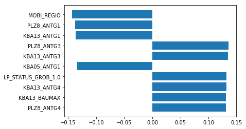

```python
pca_detail(pca20,azdias2.columns)
```

- moving mobility(mobi): high (neg)
- num of 1-2 family houses(antg1): low (neg)
- num of 6-10 family houses(antg3): high (pos)
- num of >10 family houses(antg4): high (pos)
- social status(LP_STATUS_GROB): low-income (pos:1)
- most common building type(BAUMAX): more family-homes or business buildings (pos)

high mobility, large family area, crowed area, low-income

```
PCA Dimension 1 :
```

|  | 0 | 1 | 2 | 3 | 4 | 5 | 6 | 7 | 8 | 9 |
| --- | --- | --- | --- | --- | --- | --- | --- | --- | --- | --- |
| features | KBA13_HERST_BMW_BENZ | KBA13_SEG_OBEREMITTELKLASSE | KBA13_MERCEDES | KBA13_SITZE_5 | KBA13_BMW | KBA13_SITZE_4 | KBA13_SEG_SPORTWAGEN | KBA05_HERST1 | KBA13_KMH_140_210 | KBA13_SEG_KLEINWAGEN |
| weights | 0.175052 | 0.150754 | 0.149727 | -0.146447 | 0.146139 | 0.144331 | 0.136818 | 0.12516 | -0.122488 | -0.121591 |

```
<BarContainer object of 10 artists>
```

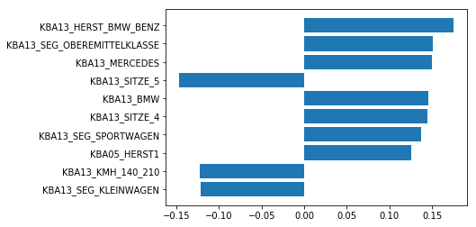

```python
pca_detail(pca20,azdias2.columns,1)
```

- BMW & BENZ share: high (pos)
- mid & upper class cars share: high (pos)
- MERCEDES share: high (pos)
- num of 5 seat cars(sitze_5): low (neg)
- bmw share: high (pos)
- num of less than 5 seat cars: high (pos)
- sportscars share: high (pos)
- top German manufacturer: high (pos)
- max speed 140-210km/h cars share: low (neg)
- small cars share: low (neg)

upper class cars, fast sports cars, German cars

```
PCA Dimension 2 :
```

|  | 0 | 1 | 2 | 3 | 4 | 5 | 6 | 7 | 8 | 9 |
| --- | --- | --- | --- | --- | --- | --- | --- | --- | --- | --- |
| features | CJT_TYP_1 | FINANZ_SPARER | CJT_TYP_2 | ALTERSKATEGORIE_GROB | FINANZ_VORSORGER | FINANZ_UNAUFFAELLIGER | CJT_TYP_5 | FINANZ_ANLEGER | CJT_TYP_4 | SEMIO_PFLICHT |
| weights | -0.184918 | -0.183318 | -0.178912 | 0.174045 | 0.173939 | -0.168233 | 0.166972 | -0.164744 | 0.161517 | -0.15814 |

```
<BarContainer object of 10 artists>
```

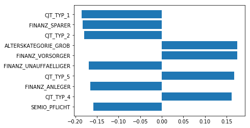

```python
pca_detail(pca20,azdias2.columns,2)
```

- Advertising- and Consumption minimalist(CJT_TYP_1): low (neg)
- money saver(FINANZ_SPARER): no/low (neg)
- Advertising- and Consumption traditionalist(CJT_TYP_2): low (neg)
- age classification(ALTERSKATEGORIE_GROB): old (pos)
- financial type be prepared: low (pos)
- financial type unremarkable: high (neg)
- Advertising- and Cross-Channel-Enthusiast(CJT_TYP_5): high (pos)
- financial type investor: high (neg)
- advertising interested Online-shopper(CJT_TYP_4): high (pos)
- dutyfull traditional minded: high (neg)

active buyer, not young and not poor

##### Kmeans cluster number selection

```python
batch_size = int(len(azdias_scaled_pca)*.01)
print(batch_size)

scores = []
for i in range(45):
    km = MiniBatchKMeans(n_clusters = i+1, batch_size = batch_size)
    km.fit(azdias_scaled_pca)

    scores.append(np.abs(km.score(azdias_scaled_pca)))
    print(i,km.score(azdias_scaled_pca))
```

```
7343
0 -121520843.41670565
1 -104707692.74991034
2 -98544805.51590961
3 -93193862.88162723
4 -89940404.97174014
5 -86551800.25298247
6 -84344906.93663155
7 -82621270.98566851
8 -79587882.43858947
9 -78510305.12421449
10 -77574133.72878656
11 -75815003.73627143
12 -75546557.20631103
13 -73258454.96599077
```

[output cut: 31 more lines]

From below plots, we see a limited score increase after 10 cluster Kmeans. So `10` is selected as a reasonable cluster number for further analysis.

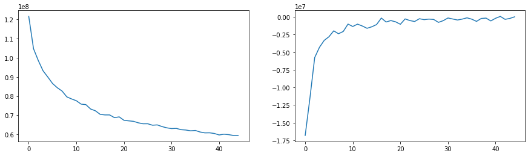

```python
f,ax = plt.subplots(figsize=(15,4))

ax = plt.subplot(1,2,1)
plt.plot(scores)

ax = plt.subplot(1,2,2)
plt.plot(np.gradient(scores))
```

## Part 1: Customer Segmentation Report

The main bulk of your analysis will come in this part of the project. Here, you should use unsupervised learning techniques to describe the relationship between the demographics of the company's existing customers and the general population of Germany. By the end of this part, you should be able to describe parts of the general population that are more likely to be part of the mail-order company's main customer base, and which parts of the general population are less so.

```python
def clean_data(df,df_dict,col_list=asdias_col0):
    # clean data type issues for each column
    df = preproc_na_typ(df,df_dict)

    # feature engineering on CAMEO_INTL_2015
    df['CAMEO_INTL_2015a'] = df['CAMEO_INTL_2015'].apply(lambda x:np.nan if str(x)=='nan' else int(str(x)[0]))
    df['CAMEO_INTL_2015b'] = df['CAMEO_INTL_2015'].apply(lambda x:np.nan if str(x)=='nan' else int(str(x)[1]))

    # drop null columns that already confirmed before
    df = df[col_list]

    # remove null rows
    df['chk'] = df.isnull().sum(axis=1).apply(lambda x:1 if x>20 else 0)
    df = df[df['chk']==0]
    df.drop('chk',axis=1,inplace=True)

    # one-hot encode for category columns
    df = pd.get_dummies(df)

    # fill na with most frequent values
    for i in df.columns[df.isnull().any()].tolist():
        top_val = df.groupby(i).size().sort_values(ascending=False).index[0]
        df[i].fillna(top_val, inplace=True)

    return df
```

### Clean Dataset and make sure `azdiaz` and `customers` have same columns.

```python
df_a = clean_data(azdias.copy(),feature_dict)
df_c = clean_data(customers.copy(),feature_dict)

for i in list(set(df_a.columns)-set(df_c.columns)):
    df_c[i] = 0
df_c = df_c[df_a.columns]

df_a.head()
```

```
2019-03-22 18:11:52.525719 Processed: 20
2019-03-22 18:12:07.043871 Processed: 40
2019-03-22 18:12:21.514609 Processed: 60
2019-03-22 18:12:35.874867 Processed: 80
2019-03-22 18:12:56.903218 Processed: 100
2019-03-22 18:13:12.469112 Processed: 120
2019-03-22 18:13:27.222989 Processed: 140
2019-03-22 18:13:43.132577 Processed: 160
2019-03-22 18:13:58.305385 Processed: 180
2019-03-22 18:14:12.740131 Processed: 200
2019-03-22 18:14:27.117993 Processed: 220
2019-03-22 18:14:41.455421 Processed: 240
2019-03-22 18:14:55.820170 Processed: 260
2019-03-22 18:15:10.192442 Processed: 280
2019-03-22 18:15:24.567153 Processed: 300
2019-03-22 18:15:42.406003 Processed: 320
2019-03-22 18:15:57.211144 Processed: 340
2019-03-22 18:16:12.515676 Processed: 360
```

```
2019-03-22 18:16:41.082097 Processed: 20
2019-03-22 18:16:44.121833 Processed: 40
2019-03-22 18:16:47.217621 Processed: 60
2019-03-22 18:16:50.299089 Processed: 80
2019-03-22 18:16:54.482664 Processed: 100
2019-03-22 18:16:57.721627 Processed: 120
2019-03-22 18:17:00.704506 Processed: 140
2019-03-22 18:17:03.932407 Processed: 160
2019-03-22 18:17:07.034307 Processed: 180
2019-03-22 18:17:09.970009 Processed: 200
2019-03-22 18:17:12.884388 Processed: 220
2019-03-22 18:17:15.800609 Processed: 240
2019-03-22 18:17:18.718360 Processed: 260
2019-03-22 18:17:21.639936 Processed: 280
2019-03-22 18:17:24.563259 Processed: 300
2019-03-22 18:17:28.200678 Processed: 320
2019-03-22 18:17:31.293422 Processed: 340
2019-03-22 18:17:34.482494 Processed: 360
```

|  | AKT_DAT_KL | ALTERSKATEGORIE_FEIN | ANZ_HAUSHALTE_AKTIV | ANZ_HH_TITEL | ANZ_KINDER | ANZ_PERSONEN | ANZ_STATISTISCHE_HAUSHALTE | ANZ_TITEL | ARBEIT | BALLRAUM | ... | VERS_TYP_1.0 | VERS_TYP_2.0 | ZABEOTYP_1 | ZABEOTYP_2 | ZABEOTYP_3 | ZABEOTYP_4 | ZABEOTYP_5 | ZABEOTYP_6 | ANREDE_KZ_1 | ANREDE_KZ_2 |
| --- | --- | --- | --- | --- | --- | --- | --- | --- | --- | --- | --- | --- | --- | --- | --- | --- | --- | --- | --- | --- | --- |
| 1 | 9.0 | 21.0 | 11.0 | 0.0 | 0.0 | 2.0 | 12.0 | 0.0 | 3.0 | 6.0 | ... | 0 | 1 | 0 | 0 | 0 | 0 | 1 | 0 | 0 | 1 |
| 2 | 9.0 | 17.0 | 10.0 | 0.0 | 0.0 | 1.0 | 7.0 | 0.0 | 3.0 | 2.0 | ... | 1 | 0 | 0 | 0 | 0 | 0 | 1 | 0 | 0 | 1 |
| 3 | 1.0 | 13.0 | 1.0 | 0.0 | 0.0 | 0.0 | 2.0 | 0.0 | 2.0 | 4.0 | ... | 1 | 0 | 0 | 0 | 1 | 0 | 0 | 0 | 0 | 1 |
| 4 | 1.0 | 14.0 | 3.0 | 0.0 | 0.0 | 4.0 | 3.0 | 0.0 | 4.0 | 2.0 | ... | 0 | 1 | 0 | 0 | 0 | 1 | 0 | 0 | 1 | 0 |
| 5 | 1.0 | 10.0 | 5.0 | 0.0 | 0.0 | 1.0 | 2.0 | 0.0 | 2.0 | 6.0 | ... | 0 | 1 | 0 | 0 | 0 | 1 | 0 | 0 | 0 | 1 |

5 rows × 539 columns

```python
df_a.shape,df_c.shape
```

```
((734341, 539), (132697, 539))
```

```python
set(df_a.columns)-set(df_c.columns),set(df_c.columns)-set(df_a.columns)
```

```
(set(), set())
```

### Train and save the Scaler

```python
scaler = StandardScaler()
data_a2 = scaler.fit_transform(df_a)

df_a2 = pd.DataFrame(data=data_a2, index=df_a.index, columns=df_a.columns)
df_a2.head()
```

|  | AKT_DAT_KL | ALTERSKATEGORIE_FEIN | ANZ_HAUSHALTE_AKTIV | ANZ_HH_TITEL | ANZ_KINDER | ANZ_PERSONEN | ANZ_STATISTISCHE_HAUSHALTE | ANZ_TITEL | ARBEIT | BALLRAUM | ... | VERS_TYP_1.0 | VERS_TYP_2.0 | ZABEOTYP_1 | ZABEOTYP_2 | ZABEOTYP_3 | ZABEOTYP_4 | ZABEOTYP_5 | ZABEOTYP_6 | ANREDE_KZ_1 | ANREDE_KZ_2 |
| --- | --- | --- | --- | --- | --- | --- | --- | --- | --- | --- | --- | --- | --- | --- | --- | --- | --- | --- | --- | --- | --- |
| 1 | 1.260460 | 1.560398 | 0.186421 | -0.125357 | -0.299106 | 0.223700 | 0.335475 | -0.060624 | -0.183045 | 0.849453 | ... | -0.907892 | 0.995192 | -0.427432 | -0.192365 | -0.740434 | -0.597351 | 2.948930 | -0.313743 | -0.958497 | 0.958497 |
| 2 | 1.260460 | 0.673877 | 0.120203 | -0.125357 | -0.299106 | -0.635082 | -0.031894 | -0.060624 | -0.183045 | -0.980639 | ... | 1.101452 | -1.004831 | -0.427432 | -0.192365 | -0.740434 | -0.597351 | 2.948930 | -0.313743 | -0.958497 | 0.958497 |
| 3 | -0.935447 | -0.212644 | -0.475767 | -0.125357 | -0.299106 | -1.493864 | -0.399263 | -0.060624 | -1.188897 | -0.065593 | ... | 1.101452 | -1.004831 | -0.427432 | -0.192365 | 1.350559 | -0.597351 | -0.339106 | -0.313743 | -0.958497 | 0.958497 |
| 4 | -0.935447 | 0.008986 | -0.343329 | -0.125357 | -0.299106 | 1.941264 | -0.325789 | -0.060624 | 0.822808 | -0.980639 | ... | -0.907892 | 0.995192 | -0.427432 | -0.192365 | -0.740434 | 1.674059 | -0.339106 | -0.313743 | 1.043300 | -1.043300 |
| 5 | -0.935447 | -0.877535 | -0.210892 | -0.125357 | -0.299106 | -0.635082 | -0.399263 | -0.060624 | -1.188897 | 0.849453 | ... | -0.907892 | 0.995192 | -0.427432 | -0.192365 | -0.740434 | 1.674059 | -0.339106 | -0.313743 | -0.958497 | 0.958497 |

5 rows × 539 columns

### Train and save the PCA model with `n_components=20`

```python
n_components = 20
pca20 = PCA(n_components = n_components,random_state=42)
df_a2_pca = pca20.fit_transform(df_a2)
pca20.components_.shape
```

```
(20, 539)
```

### Train and save the Kmeans model with `n_clusters=10`

```python
km = KMeans(n_clusters = 10, random_state = 42)
km.fit(df_a2_pca)
```

```
KMeans(algorithm='auto', copy_x=True, init='k-means++', max_iter=300,
    n_clusters=10, n_init=10, n_jobs=1, precompute_distances='auto',
    random_state=42, tol=0.0001, verbose=0)
```

### Transform `customers` dataset based on models above

```python
def cluster_predict(df0,scaler,pca,km):
    df = pd.DataFrame(data=scaler.transform(df0.copy()), index=df0.index, columns=df0.columns)
    df = pca.transform(df)
    df0['cluster'] = km.predict(df)
    return df0
```

```python
df_a = cluster_predict(df_a,scaler,pca20,km)
df_c = cluster_predict(df_c,scaler,pca20,km)
```

### Assign cluster info to both dataset and analyze their distribution

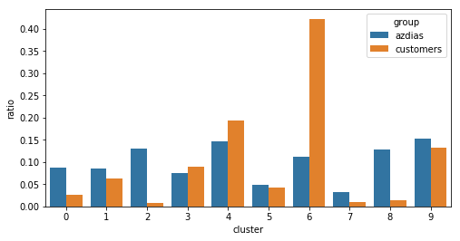

```python
f,ax = plt.subplots(figsize=(8,4))
dfa = pd.DataFrame()
dfa['ratio'] = df_a.groupby('cluster').size()/len(df_a)
dfa['group'] = 'azdias'
dfa = dfa.reset_index()

dfc = pd.DataFrame()
dfc['ratio'] = df_c.groupby('cluster').size()/len(df_c)
dfc['group'] = 'customers'
dfc = dfc.reset_index()

dft = pd.concat([dfa,dfc])
sns.barplot(x='cluster',y='ratio',hue='group',data=dft,ax=ax)
```

### Analysis:

Based on Kmeans cluster, it is clear to see that `Cluster 6` is outstanding for `customers`, which means people in this group is more likely to be part of the mail-order company's main customer base than other groups.

Now let's look inside **Cluster 6** for detailed characteristics:

```python
km.cluster_centers_[6]
```

```
array([-6.17289942,  2.63805489,  2.70218727,  2.11186244, -0.41675311,
        0.17865808, -1.31227726, -1.44491091,  0.05423131,  0.52463946,
       -0.45466946, -1.3525295 , -1.34697778, -0.24049789,  1.08152205,
        0.20592145,  0.26576592,  0.76973664,  0.76512887,  0.17711268])
```

##### The starting 4 PCA features have the largest absolute value of coefficient, with negative impact on the first one (-6.1728).

Following are the observation for each PCA feature:

Please reference to detailed diagrams below.

**In conclusion**, for the entire population, people who are in the middle age, with good income level, have upper class cars, and comfortable with online shopping are most likely to be part of the mail-order company's main customer base.

```
PCA Dimension 0 :
```

|  | 0 | 1 | 2 | 3 | 4 | 5 | 6 | 7 | 8 | 9 |
| --- | --- | --- | --- | --- | --- | --- | --- | --- | --- | --- |
| features | MOBI_REGIO | PLZ8_ANTG1 | KBA13_ANTG1 | PLZ8_ANTG3 | KBA13_ANTG3 | KBA05_ANTG1 | LP_STATUS_GROB_1.0 | KBA13_ANTG4 | KBA13_BAUMAX | PLZ8_ANTG4 |
| weights | -0.143068 | -0.137414 | -0.136721 | 0.135768 | 0.134916 | -0.133355 | 0.132165 | 0.132038 | 0.131283 | 0.130747 |

```
<BarContainer object of 10 artists>
```

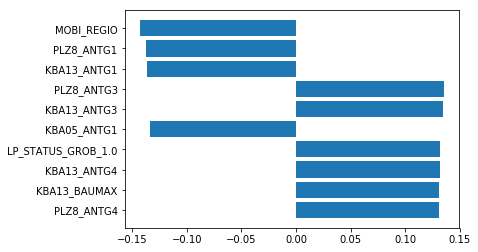

```python
pca_detail(pca20,azdias2.columns,0)
```

```
PCA Dimension 1 :
```

|  | 0 | 1 | 2 | 3 | 4 | 5 | 6 | 7 | 8 | 9 |
| --- | --- | --- | --- | --- | --- | --- | --- | --- | --- | --- |
| features | KBA13_HERST_BMW_BENZ | KBA13_SEG_OBEREMITTELKLASSE | KBA13_MERCEDES | KBA13_SITZE_5 | KBA13_BMW | KBA13_SITZE_4 | KBA13_SEG_SPORTWAGEN | KBA05_HERST1 | KBA13_KMH_140_210 | KBA13_SEG_KLEINWAGEN |
| weights | 0.175052 | 0.150754 | 0.149727 | -0.146447 | 0.146139 | 0.144331 | 0.136818 | 0.12516 | -0.122488 | -0.121591 |

```
<BarContainer object of 10 artists>
```

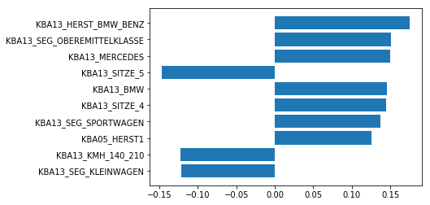

```python
pca_detail(pca20,azdias2.columns,1)
```

```
PCA Dimension 2 :
```

|  | 0 | 1 | 2 | 3 | 4 | 5 | 6 | 7 | 8 | 9 |
| --- | --- | --- | --- | --- | --- | --- | --- | --- | --- | --- |
| features | CJT_TYP_1 | FINANZ_SPARER | CJT_TYP_2 | ALTERSKATEGORIE_GROB | FINANZ_VORSORGER | FINANZ_UNAUFFAELLIGER | CJT_TYP_5 | FINANZ_ANLEGER | CJT_TYP_4 | SEMIO_PFLICHT |
| weights | -0.184918 | -0.183318 | -0.178912 | 0.174045 | 0.173939 | -0.168233 | 0.166972 | -0.164744 | 0.161517 | -0.15814 |

```
<BarContainer object of 10 artists>
```

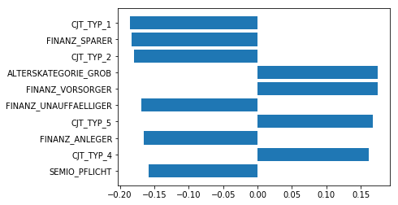

```python
pca_detail(pca20,azdias2.columns,2)
```

```
PCA Dimension 3 :
```

|  | 0 | 1 | 2 | 3 | 4 | 5 | 6 | 7 | 8 | 9 |
| --- | --- | --- | --- | --- | --- | --- | --- | --- | --- | --- |
| features | VK_DISTANZ | VK_DHT4A | VK_ZG11 | LP_FAMILIE_GROB_1.0 | LP_FAMILIE_FEIN_1.0 | D19_KONSUMTYP_MAX | ONLINE_AFFINITAET | ANZ_PERSONEN | D19_GESAMT_ONLINE_QUOTE_12 | D19_VERSAND_ONLINE_QUOTE_12 |
| weights | -0.186304 | -0.17774 | -0.168033 | -0.15476 | -0.15476 | -0.151132 | 0.148316 | 0.138614 | 0.131182 | 0.126564 |

```
<BarContainer object of 10 artists>
```

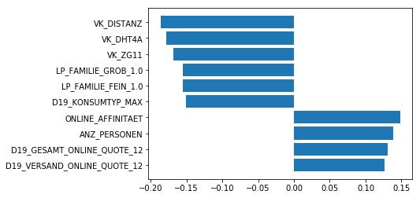

```python
pca_detail(pca20,azdias2.columns,3)
```

## Part 2: Supervised Learning Model

Now that you've found which parts of the population are more likely to be customers of the mail-order company, it's time to build a prediction model. Each of the rows in the "MAILOUT" data files represents an individual that was targeted for a mailout campaign. Ideally, we should be able to use the demographic information from each individual to decide whether or not it will be worth it to include that person in the campaign.

The "MAILOUT" data has been split into two approximately equal parts, each with almost 43 000 data rows. In this part, you can verify your model with the "TRAIN" partition, which includes a column, "RESPONSE", that states whether or not a person became a customer of the company following the campaign. In the next part, you'll need to create predictions on the "TEST" partition, where the "RESPONSE" column has been withheld.

```python
#mailout_train = pd.read_csv('../../data/Term2/capstone/arvato_data/Udacity_MAILOUT_052018_TRAIN.csv', sep=';')
```

### Model selection

For prediction, I picked **Xgboost**, which is a popular non-linear model for real world problems.

In this section, I am not going to drop any features columns or rows, in order to maintain information as much as possible.

The main work for preprocessing, is transforming missing values into `np.nan`, labelling numerical and categorical columns, and one-hot encoding the categorical ones.

Also, as far as Xgboost is an non-linear model, I did not scale the data. In addition, I left all Null cells alone, because Xgboost is able to dealing with them by default.

```python
def preproc_data(df,df_dict):
    # clean data type issues for each column
    df = preproc_na_typ(df,df_dict)

    df['CAMEO_INTL_2015a'] = df['CAMEO_INTL_2015'].apply(lambda x:np.nan if str(x)=='nan' else int(str(x)[0]))
    df['CAMEO_INTL_2015b'] = df['CAMEO_INTL_2015'].apply(lambda x:np.nan if str(x)=='nan' else int(str(x)[1]))
    df = df.drop(['CAMEO_INTL_2015'],axis=1)

    df = pd.get_dummies(df)
    return df
```

```python
df_train = preproc_data(df_train0.copy(),feature_dict)#clean_data(df_train.copy(),feature_dict,ptype='train')
df_test = preproc_data(df_test0.copy(),feature_dict)#clean_data(df_test.copy(),feature_dict,ptype='train')
```

[output not shown]

```python
list(set(df_train.columns)-set(df_test.columns)),list(set(df_test.columns)-set(df_train.columns))
```

```
(['D19_LOTTO_4.0', 'RESPONSE', 'D19_HANDWERK_1.0'], ['D19_BIO_OEKO_1.0'])
```

```python
for i in list(set(df_train.columns)-set(df_test.columns)):
    if i == 'RESPONSE':
        continue
    df_train = df_train.drop([i],axis=1)

for i in list(set(df_test.columns)-set(df_train.columns)):
    df_test = df_test.drop([i],axis=1)
```

```python
list(set(df_train.columns)-set(df_test.columns)),list(set(df_test.columns)-set(df_train.columns))
```

```
(['RESPONSE'], [])
```

```python
df_train = df_train.merge(customers[['LNR','CUSTOMER_GROUP','ONLINE_PURCHASE','PRODUCT_GROUP']],how='left',on='LNR')
df_train.shape
```

```
(42962, 817)
```

```python
df_test = df_test.merge(customers[['LNR','CUSTOMER_GROUP','ONLINE_PURCHASE','PRODUCT_GROUP']],how='left',on='LNR')
df_test.shape
```

```
(42833, 816)
```

### Add Extra features

By checking user_id column `LNR`, it is clear that people in both train and test dataset are recorded in `customers` as well. So we are able to merge extra features (`CUSTOMER_GROUP`,`PRODUCT_GROUP`,`PRODUCT_GROUP`) into train and test set.

```python
df_train['CUSTOMER_GROUP'] = df_train['CUSTOMER_GROUP'].apply(lambda x:1 if x=='SINGLE_BUYER' else 0)
df_test['CUSTOMER_GROUP'] = df_test['CUSTOMER_GROUP'].apply(lambda x:1 if x=='SINGLE_BUYER' else 0)
df_train['PRODUCT_GROUP1'] = df_train['PRODUCT_GROUP'].apply(lambda x:1 if 'FOOD' in x else 0)
df_train['PRODUCT_GROUP2'] = df_train['PRODUCT_GROUP'].apply(lambda x:1 if 'COSMETIC' in x else 0)
df_test['PRODUCT_GROUP1'] = df_test['PRODUCT_GROUP'].apply(lambda x:1 if 'FOOD' in x else 0)
df_test['PRODUCT_GROUP2'] = df_test['PRODUCT_GROUP'].apply(lambda x:1 if 'COSMETIC' in x else 0)
df_train = df_train.drop(['PRODUCT_GROUP'],axis=1)
df_test = df_test.drop(['PRODUCT_GROUP'],axis=1)
df_train[['LNR','CUSTOMER_GROUP','ONLINE_PURCHASE','PRODUCT_GROUP1','PRODUCT_GROUP2']].head()
```

|  | LNR | CUSTOMER_GROUP | ONLINE_PURCHASE | PRODUCT_GROUP1 | PRODUCT_GROUP2 |
| --- | --- | --- | --- | --- | --- |
| 0 | 1763 | 0 | 0 | 1 | 1 |
| 1 | 1771 | 0 | 0 | 1 | 1 |
| 2 | 1776 | 0 | 1 | 1 | 1 |
| 3 | 1460 | 0 | 0 | 1 | 1 |
| 4 | 1783 | 0 | 0 | 1 | 1 |

```python
list(set(df_train.columns)-set(df_test.columns)),list(set(df_test.columns)-set(df_train.columns))
```

```
(['RESPONSE'], [])
```

```python
df_train['RESPONSE'].value_counts()
```

```
0    42430
1      532
Name: RESPONSE, dtype: int64
```

```python
y = df_train['RESPONSE']
X = df_train.drop(['RESPONSE'], axis=1)
print(X.shape, y.shape)
```

```
(42962, 817) (42962,)
```

```python
X.columns
```

```
Index(['LNR', 'AKT_DAT_KL', 'ALTER_HH', 'ALTER_KIND1', 'ALTER_KIND2',
       'ALTER_KIND3', 'ALTER_KIND4', 'ALTERSKATEGORIE_FEIN',
       'ANZ_HAUSHALTE_AKTIV', 'ANZ_HH_TITEL',
       ...
       'ZABEOTYP_3', 'ZABEOTYP_4', 'ZABEOTYP_5', 'ZABEOTYP_6', 'ANREDE_KZ_1',
       'ANREDE_KZ_2', 'CUSTOMER_GROUP', 'ONLINE_PURCHASE', 'PRODUCT_GROUP1',
       'PRODUCT_GROUP2'],
      dtype='object', length=817)
```

```python
train_cols = X.columns[1:]
train_cols
```

```
Index(['AKT_DAT_KL', 'ALTER_HH', 'ALTER_KIND1', 'ALTER_KIND2', 'ALTER_KIND3',
       'ALTER_KIND4', 'ALTERSKATEGORIE_FEIN', 'ANZ_HAUSHALTE_AKTIV',
       'ANZ_HH_TITEL', 'ANZ_KINDER',
       ...
       'ZABEOTYP_3', 'ZABEOTYP_4', 'ZABEOTYP_5', 'ZABEOTYP_6', 'ANREDE_KZ_1',
       'ANREDE_KZ_2', 'CUSTOMER_GROUP', 'ONLINE_PURCHASE', 'PRODUCT_GROUP1',
       'PRODUCT_GROUP2'],
      dtype='object', length=816)
```

### Model Training

```python
X_train, X_test, y_train, y_test = train_test_split(X[train_cols], y, random_state=42, test_size=0.2)
```

```python
clf = XGBClassifier(verbose=1)
```

```python
%%time
clf.fit(X_train,
        y_train,
        eval_metric='auc',
        verbose=True,
        eval_set=[(X_test, y_test)],
        early_stopping_rounds=50
       )
```

```
Will train until validation_0-auc hasn't improved in 50 rounds.
Stopping. Best iteration:

CPU times: user 45.5 s, sys: 204 ms, total: 45.7 s
Wall time: 45.7 s
```

```
XGBClassifier(base_score=0.5, booster='gbtree', colsample_bylevel=1,
       colsample_bytree=1, gamma=0, learning_rate=0.1, max_delta_step=0,
       max_depth=3, min_child_weight=1, missing=None, n_estimators=100,
       n_jobs=1, nthread=None, objective='binary:logistic', random_state=0,
       reg_alpha=0, reg_lambda=1, scale_pos_weight=1, seed=None,
       silent=True, subsample=1, verbose=1)
```

```python
clf.get_params()
```

```
{'base_score': 0.5,
 'booster': 'gbtree',
 'colsample_bylevel': 1,
 'colsample_bytree': 1,
 'gamma': 0,
 'learning_rate': 0.1,
 'max_delta_step': 0,
 'max_depth': 3,
 'min_child_weight': 1,
 'missing': None,
 'n_estimators': 100,
 'n_jobs': 1,
 'nthread': None,
 'objective': 'binary:logistic',
 'random_state': 0,
 'reg_alpha': 0,
 'reg_lambda': 1,
 'scale_pos_weight': 1,
 'seed': None,
 'silent': True,
 'subsample': 1,
 'verbose': 1}
```

### Display feature importance

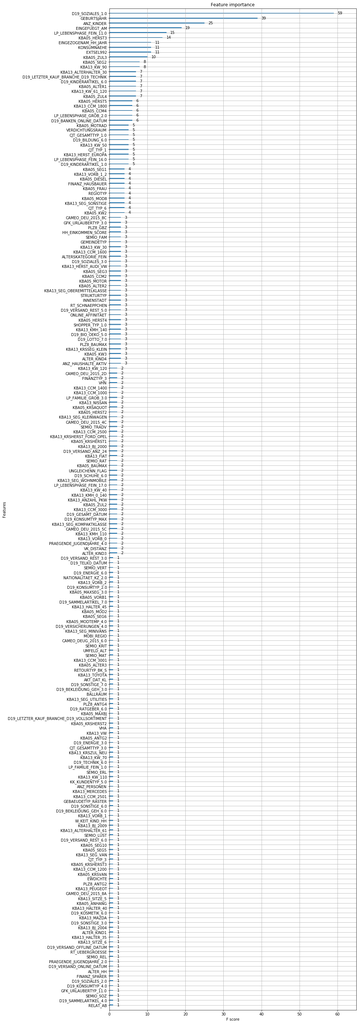

```python
import xgboost as xgb
fig,ax=plt.subplots(figsize=(12,50))
xgb.plot_importance(clf,ax=ax)
```

### Analysis

**Undocumented but important features**: From feature importance plot, we do see some top features which are not documented, such as `D19_SOZIALES`, `ANZ_KINDER`, `EXTSEL992`, and so on.

## Part 3: Kaggle Competition

Now that you've created a model to predict which individuals are most likely to respond to a mailout campaign, it's time to test that model in competition through Kaggle. If you click on the link [here](http://www.kaggle.com/t/21e6d45d4c574c7fa2d868f0e8c83140), you'll be taken to the competition page where, if you have a Kaggle account, you can enter. If you're one of the top performers, you may have the chance to be contacted by a hiring manager from Arvato or Bertelsmann for an interview!

Your entry to the competition should be a CSV file with two columns. The first column should be a copy of "LNR", which acts as an ID number for each individual in the "TEST" partition. The second column, "RESPONSE", should be some measure of how likely each individual became a customer – this might not be a straightforward probability. As you should have found in Part 2, there is a large output class imbalance, where most individuals did not respond to the mailout. Thus, predicting individual classes and using accuracy does not seem to be an appropriate performance evaluation method. Instead, the competition will be using AUC to evaluate performance. The exact values of the "RESPONSE" column do not matter as much: only that the higher values try to capture as many of the actual customers as possible, early in the ROC curve sweep.

```python
#mailout_test = pd.read_csv('../../data/Term2/capstone/arvato_data/Udacity_MAILOUT_052018_TEST.csv', sep=';')
```

```python
y_test_final = clf.predict_proba(df_test[train_cols])[:, 1]
y_test_final
```

```
array([0.03104344, 0.03336287, 0.00540125, ..., 0.02075526, 0.03793916,
       0.0316454 ], dtype=float32)
```

```python
df_test['RESPONSE'] = y_test_final
df_test[['LNR', 'RESPONSE']].to_csv('response1.csv', index=False)
```